# Metodo Arima estimación de Datos

Esto es un Estudio de Metodo Arima para la estimación del valor y su análisis, la data tomado de: MSFT yahoo.finance.com https://es-us.finanzas.yahoo.com/quote/MSFT/history?p=MSFT

1. Importing packages Se debe añadir {r load_libraries, warning=FALSE, message=FALSE} para evitar mensajes de error.

```r
library(tidyverse) # metapackage of all tidyverse packages
library(dplyr)
library (GGally)
library(ggplot2)
library(ggrepel)
library(lubridate)
library(rpart)
library(tidyr)
library(forecast)
```

```r
msft <-read_csv("D:/d/2-ESTUDIO/R/LIbro Power bi R Python/seccion 2/Seccion II R/MSFT.csv")
```

```r
msft$Date <-as.Date(msft$Date,"%d.%m.%Y")

head(msft)
```

| Date | Open | High | Low | Close | Adj Close | Volume |
| --- | --- | --- | --- | --- | --- | --- |
| 2016-03-07 | 51.56 | 51.80 | 50.58 | 51.03 | 46.79306 | 38407800 |
| 2016-03-08 | 50.80 | 52.13 | 50.60 | 51.65 | 47.36159 | 33835100 |
| 2016-03-09 | 51.89 | 52.85 | 51.86 | 52.84 | 48.45279 | 28251600 |
| 2016-03-10 | 52.93 | 52.94 | 51.16 | 52.05 | 47.72837 | 38387800 |
| 2016-03-11 | 53.00 | 53.07 | 52.38 | 53.07 | 48.66370 | 32275700 |
| 2016-03-14 | 52.71 | 53.59 | 52.63 | 53.17 | 48.75539 | 24083600 |

```r
NA
```

Los datos representas los valores de las acciones por fecha, la columna Close represnta el valor de cierre. Se usará el metodo Arima para pronosticar el valor en 180 días.

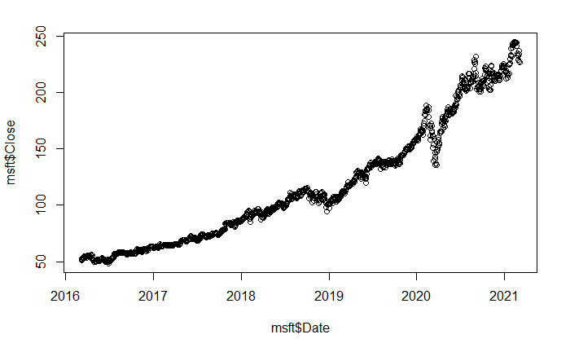

```r
plot(msft$Date,msft$Close)
```

```r
ts <-ts(msft,start = c(2016,03,7),frequency = 260) # 260 intervalos equivalente a 52 semana por 5 días
modelo <- auto.arima(ts[,5]) # columna 5 Close
pronostico<- forecast(modelo,180,level=95)#

pronostico
```

|  | Point Forecast | Lo 95 | Hi 95 |
| --- | --- | --- | --- |
| 2020.846 | 227.1405 | 222.4035 | 231.8774 |
| 2020.850 | 227.2047 | 221.3653 | 233.0441 |
| 2020.854 | 227.3656 | 220.4075 | 234.3237 |
| 2020.858 | 227.4995 | 219.6278 | 235.3711 |
| 2020.862 | 227.6409 | 218.9390 | 236.3428 |
| 2020.865 | 227.7802 | 218.3238 | 237.2367 |
| 2020.869 | 227.9201 | 217.7643 | 238.0760 |
| 2020.873 | 228.0599 | 217.2500 | 238.8698 |
| 2020.877 | 228.1997 | 216.7730 | 239.6263 |
| 2020.881 | 228.3395 | 216.3277 | 240.3512 |

[output cut: 170 more lines]

```r
NA
```

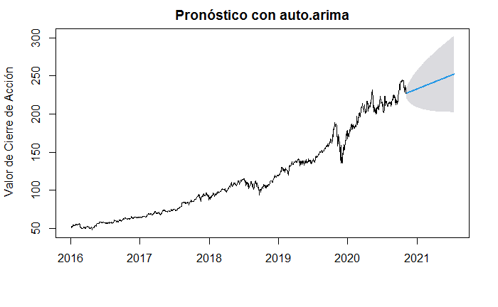

```r
plot(pronostico, main="Pronóstico con auto.arima",
ylab=" Valor de Cierre de Acción")
```

Lo que hace la función forecast es llamar al objeto con el nombre modelo, y el número de proyecciones fuera de la muestra; adicionalmente pude construir intervalos de confianza a cualquier nivel.

Para obtener esos pronósticos en una matriz (donde se guardarán los pronósticos con los intervalos de confianza solicitados), basta con realizar los siguiente:

```r
matriz.pronosticos <-data.frame(pronostico$mean,pronostico$lower,pronostico$upper)
matriz.pronosticos
```

| pronostico.mean | X95. | X95..1 |
| --- | --- | --- |
| 227.1405 | 222.4035 | 231.8774 |
| 227.2047 | 221.3653 | 233.0441 |
| 227.3656 | 220.4075 | 234.3237 |
| 227.4995 | 219.6278 | 235.3711 |
| 227.6409 | 218.9390 | 236.3428 |
| 227.7802 | 218.3238 | 237.2367 |
| 227.9201 | 217.7643 | 238.0760 |
| 228.0599 | 217.2500 | 238.8698 |
| 228.1997 | 216.7730 | 239.6263 |
| 228.3395 | 216.3277 | 240.3512 |

[output cut: 170 more lines]

```r
NA
```